# Project 2 - Text analysis, Sampling and inference

Lior Belkin (315818765)

18.5.2023

### – Part 1 - MOBY DICK –

**Solution:**

### 1. Load the data

```r
mobey_dick_html = read_html("https://www.gutenberg.org/files/2701/2701-h/2701-h.htm")
mobey_dick = html_text(html_nodes(mobey_dick_html, "body"))

print(html_text(html_nodes(mobey_dick_html, "title")))
```

```
## [1] "The Project Gutenberg eBook of Moby Dick; Or the Whale, by Herman Melville"
```

After looking at the html itself we decided to take the body and to avoid the unusual signs at the beginning, the first row of readable letters is the title.

##### b. Split the text string into list of words and analyse the distribution.

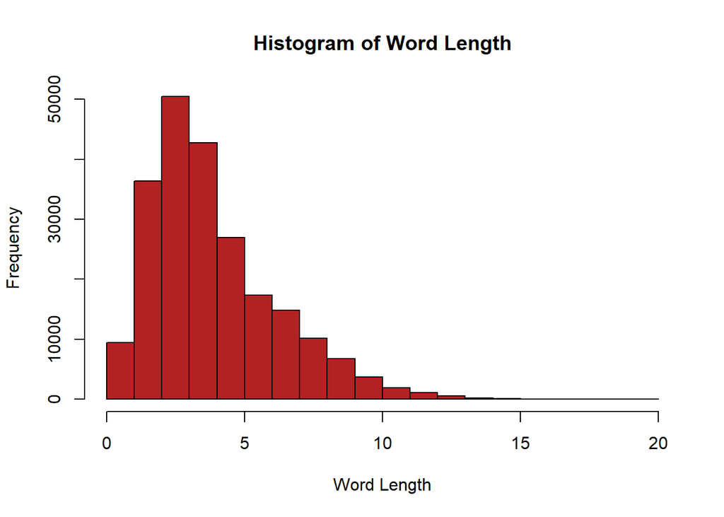

```r
mobey_words_in_line =  strsplit(mobey_dick, "\\W+")
len_vec = as.numeric(str_count(mobey_words_in_line[[1]]))
word_num = lengths(mobey_words_in_line)

hist(len_vec, main = "Histogram of Word Length",
     col = 'firebrick', xlim = c(0,20), xlab = 'Word Length')
```

```r
print(paste0('Number of words: ',word_num))
```

```
## [1] "Number of words: 222601"
```

```r
print(paste0('The median of word lengths: ', median(len_vec)))
```

```
## [1] "The median of word lengths: 4"
```

```r
print(paste0('The mean of word lengths: ', mean(len_vec)))
```

```
## [1] "The mean of word lengths: 4.36516906932134"
```

```r
print(paste0('The longest word length: ', max(len_vec)))
```

```
## [1] "The longest word length: 20"
```

```r
common_lengths = as.data.frame.table(sort(table(len_vec), decreasing = TRUE))
print(paste0('The most common word length: ',levels(droplevels(common_lengths$len_vec[1]))))
```

```
## [1] "The most common word length: 3"
```

The empirical distribution is skewed to the right, as stated and as seen in the histogram the most common length is 3.

##### c. genertae frequncies of words and sowing top 10.

```r
words_freq = as.data.frame.table(sort(table(mobey_words_in_line[[1]]), decreasing = TRUE))
names(words_freq)[1] = 'Word'
head(words_freq, n=10)
```

[output not shown]

```r
print(levels(droplevels(words_freq$Word[1:10]))) # Top 10 words
```

```
##  [1] "the"  "of"   "and"  "a"    "to"   "in"   "that" "his"  "it"   "I"
```

### 2. Spliting the text book

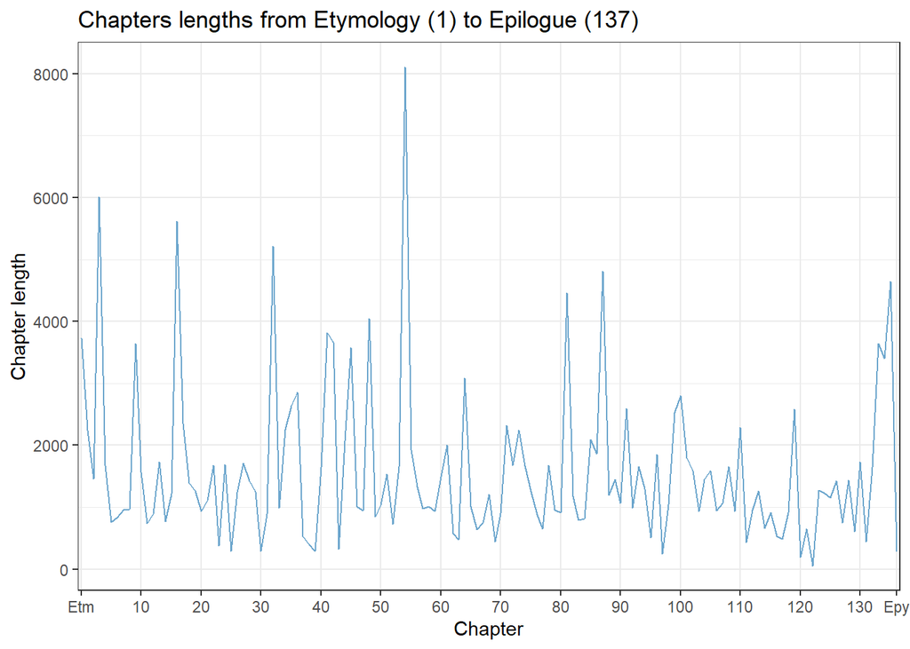

```r
mobey_substr = substr(mobey_dick, 9750, 1385371) # generate sub string from the index of etymology (9750), to the index of the epilogue ending (1385371)

all_chapters = unlist(strsplit(mobey_substr, split = "\r\n    \r\n      \r\n       \r\n    \r\n    \r\n      \r\n    \r\n"))

divided_book = list()
chpaters_lengths = c()
for (i in 1:length(all_chapters)){
  divided_book[[i]] = unlist(strsplit(all_chapters[i], "\\W+"))
  chpaters_lengths[i] = length(divided_book[[i]])
}

divided_book_array = array(divided_book)


df_for_plot = cbind.data.frame(c(1:137), chpaters_lengths)
colnames(df_for_plot) = c('chapter', 'length')
ggplot(data = df_for_plot) + aes_string(x='chapter', y='length') +
      geom_line(col="skyblue3") +
      theme_bw() +
      labs(x="Chapter", y = 'Chapter length', title=("Chapters lengths from Etymology (1) to Epilogue (137)")) +  scale_x_discrete(limits = c("Etm", seq(1,135), "Epy"), breaks = c("Etm", seq(10,135,10), "Epy"))
```

```r
print(paste0('Longest chapter: ',which.max(chpaters_lengths)))
```

```
## [1] "Longest chapter: 55"
```

```r
print(paste0('Shortest chapter: ',which.min(chpaters_lengths)))
```

```
## [1] "Shortest chapter: 123"
```

##### b. function for relative frequencies of words by chapter.

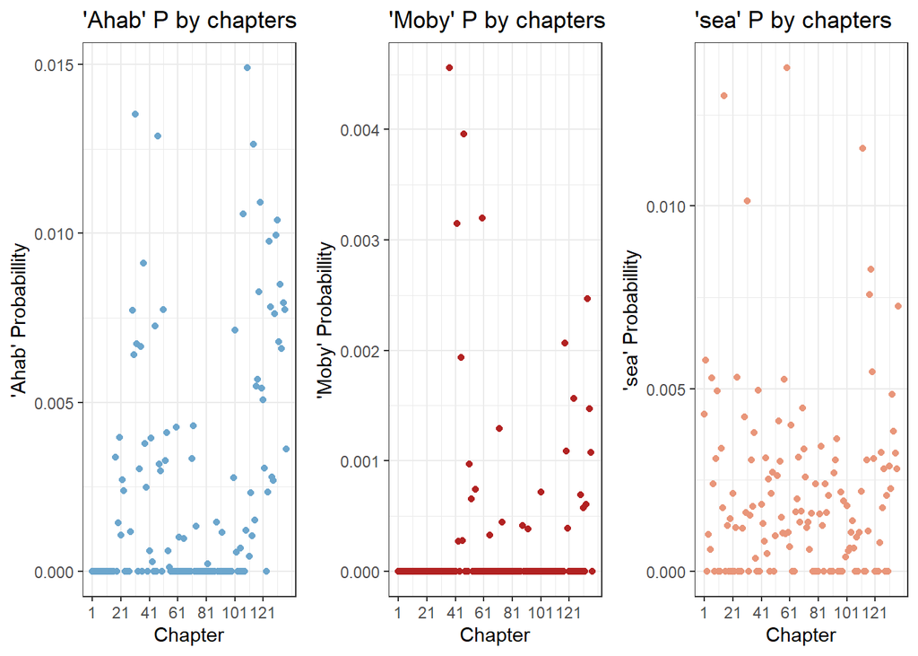

```r
genereate_word_freq = function(word, chapters){
  ctr = 0
  prob_vec = c()
  for (i in 1:137){
    for (x in chapters[[i]]){
      if (x == word){
        ctr = ctr +1
      }
    }
    prob_vec[i] = ctr / length(chapters[[i]])
    ctr = 0
  }
  prob_vec
}

Ahab_probs = genereate_word_freq('Ahab', divided_book_array)
Moby_probs = genereate_word_freq('Moby', divided_book_array)
sea_probs =  genereate_word_freq('sea',  divided_book_array)
chapter = c(1:137)
probs_df_words = cbind.data.frame(chapter, Ahab_probs, Moby_probs, sea_probs)

pl1 = ggplot(probs_df_words) + aes_string(x='chapter', y= 'Ahab_probs') +
  geom_point(col="skyblue3") + theme_bw() +
  labs(x="Chapter", y ="'Ahab' Probabillity",title=("'Ahab' P by chapters")) + scale_x_continuous(breaks = c(seq(1, 137, 20)))

pl2 = ggplot(probs_df_words) + aes_string(x='chapter', y= 'Moby_probs') +
  geom_point(col="firebrick") + theme_bw() +
  labs(x="Chapter", y ="'Moby' Probabillity",title=("'Moby' P by chapters")) + scale_x_continuous(breaks = c(seq(1, 137, 20)))


pl3 = ggplot(probs_df_words) + aes_string(x='chapter', y= 'sea_probs') +
  geom_point(col="darksalmon") + theme_bw() +
  labs(x="Chapter", y = "'sea' Probabillity", title=("'sea' P by chapters")) + scale_x_continuous(breaks = c(seq(1, 137, 20)))

ggarrange(pl1, pl2, pl3, ncol=3)
```

### 3. Probability,Caclulate&Simulate

```r
# (i)

words_prop = words_freq %>% group_by(Word) %>% summarise(same_word_freq = (Freq/word_num)^2)

sum(words_prop$same_word_freq)
```

```
## [1] 0.008497684
```

```r
# (ii)

set.seed(2)

same_word_prop_func = function(n){
  vec = mobey_words_in_line[[1]]
  ctr = 0
    for (i in 1:n){
      samp = sample(vec, 2, replace = TRUE)
      num_words = length(unique(samp))
      if (num_words == 1){
        ctr = ctr + 1
    }
    }
  return(ctr/n)
}

same_word_prop_func(100000)
```

```
## [1] 0.00908
```

1. As the pick is independent:
   $$\\[Pr(same\_{word}) = \\sum\_{i =
   1}\^{num\_{words}}p({word\^2_i}) = \\cup\_{i =
   1}\^{num\_{words}}p({word\^2_i}) \\$$
   We created a data frame that contains all the squared probabilities and than used `sum` on all the probabilities to get the union of all the probabilities (since they are independent).
2. We sampled 100000 times 2 words from the book it self and returned the number of times the same word was sampled independently.

##### b. unique words, same word probabillity

```r
unique_words = subset(words_freq, Freq == 1, select = Word) %>% filter(Word != '')

word_p  = 1/lengths(unique_words) # True for any unique word
same_unique_word_p = as.numeric(word_p)^2 # independently picking the same word

print(same_unique_word_p*length(unique_words$Word)) # sum of all options (Union)
```

```
## [1] 0.000117096
```

$$\\[Pr(same\_{word}) = \\sum\_{i =
1}\^{num\_{words}}p({word\^2_i}) =
\\cup\_{i = 1}\^{num\_{words}}p({word\^2_i}) =\^{iid} num\_{words} \*
p({word\^2_i})\\$$
There are around 8.5K of unique words compare to around 222K of total words. while checking the probability for any unique word we get (1/8.5K) its approximately (26/222K). but, since we have some very high frequent words the Union of probabilities is higher in the non-unique and we get lower probability in the unique words for same_word_p.

### 4. Extracting

```r
words_freq$Word = trimws(gsub("\\w*[0-9]+\\w*\\s*", "", words_freq$Word)) # only English

five_letters = subset(words_freq, str_count(Word) == 5) # five letters

five_letters$Word = tolower(five_letters$Word) # lower case

five_letters = aggregate(five_letters['Freq'], by=five_letters['Word'], sum) %>% arrange(desc(Freq))

five_letters_list = as.list(five_letters$Word)

print(paste0('Number of 5 letters words: ',length(five_letters_list))) # word count
```

```
## [1] "Number of 5 letters words: 2015"
```

```r
unique_five = subset(five_letters, Freq == 1, select = Word) # unique words

print(paste0('Number of unique 5 letters words: ',length(unique_five$Word))) # unique count
```

```
## [1] "Number of unique 5 letters words: 636"
```

```r
head(as.data.table(five_letters), 10)
```

[output not shown]

##### b. Compute letter frequencies statistics of the five-letter words, show on heatmap

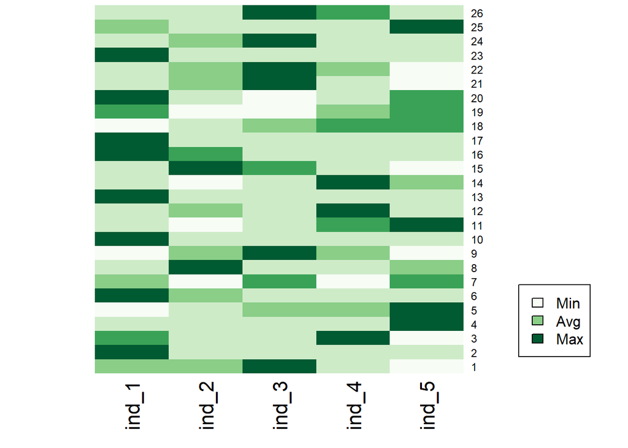

```r
connected_letters_vec = function(data, var){
  ind = rep("", 5)
  for(i in data[var]){ # ind[i] = all letters of index i in the words
    for (j in 1:5){
      ind[j] = paste(ind[j], strrep(substr(i, j, j),five_letters$Freq[five_letters$Word==i]),
                     sep = "", collapse = '')
    }
  }
return(ind)
}

five_let_ind = connected_letters_vec(five_letters, 'Word')

freq_by_ind = cbind.data.frame( # data frame of all letter freq by index
  as.data.frame(table(c(letters, strsplit(five_let_ind[1],   "")[[1]]))-1),
  as.data.frame(table(c(letters, strsplit(five_let_ind[2],   "")[[1]]))-1)[-2,]$Freq,
  as.data.frame(table(c(letters, strsplit(five_let_ind[3],   "")[[1]]))-1)$Freq,
  as.data.frame(table(c(letters, strsplit(five_let_ind[4],   "")[[1]]))-1)$Freq,
  as.data.frame(table(c(letters, strsplit(five_let_ind[5],   "")[[1]]))-1)[-2,]$Freq)


colnames(freq_by_ind) = c("Letter", "ind_1","ind_2","ind_3","ind_4","ind_5")

gen_heatmap = function(data){
  heatmap(data.matrix(data[-1]),Rowv = NA,Colv = NA, col =  colorRampPalette(brewer.pal(8, "Greens"))(5))
legend(x="bottomright", legend=c("Min", "Avg", "Max"),
       fill=colorRampPalette(brewer.pal(8, "Greens"))(3))
}

gen_heatmap(freq_by_ind)
```

##### c. function calculating likehood of five letter words, showing top 10 table

```r
generate_est = function(word, probs){ # MLE estimator by multiplying all letters prob
  splitted_word = c(unlist(strsplit(word, '')))
  w1 = subset(probs, Letter %in% splitted_word[1])$letter_prob_1
  w2 = subset(probs, Letter %in% splitted_word[2])$letter_prob_2
  w3 = subset(probs, Letter %in% splitted_word[3])$letter_prob_3
  w4 = subset(probs, Letter %in% splitted_word[4])$letter_prob_4
  w5 = subset(probs, Letter %in% splitted_word[5])$letter_prob_5
  estimator = w1 * w2 * w3 * w4 * w5
  return(estimator)
}

gen_letter_probs = function(df){
  new_df = df %>% group_by(Letter) %>% summarise(
  letter_prob_1 = ind_1 / sum(df$ind_1),
  letter_prob_2 = ind_2 / sum(df$ind_2),
  letter_prob_3 = ind_3 / sum(df$ind_3),
  letter_prob_4 = ind_4 / sum(df$ind_4),
  letter_prob_5 = ind_5 / sum(df$ind_5)) # each letter probability by index
  return(new_df)
}

letter_probs = gen_letter_probs(freq_by_ind)

word_by_estimators = five_letters %>% group_by(Word) %>%  summarise(MLE = generate_est(Word, letter_probs))
word_by_estimators = word_by_estimators[order(word_by_estimators$MLE, decreasing = TRUE), ]
# each word and it's MLE
head(word_by_estimators, 10) # top 10
```

[output not shown]

### – Part 2 - WORDLE –

### 5. Loading

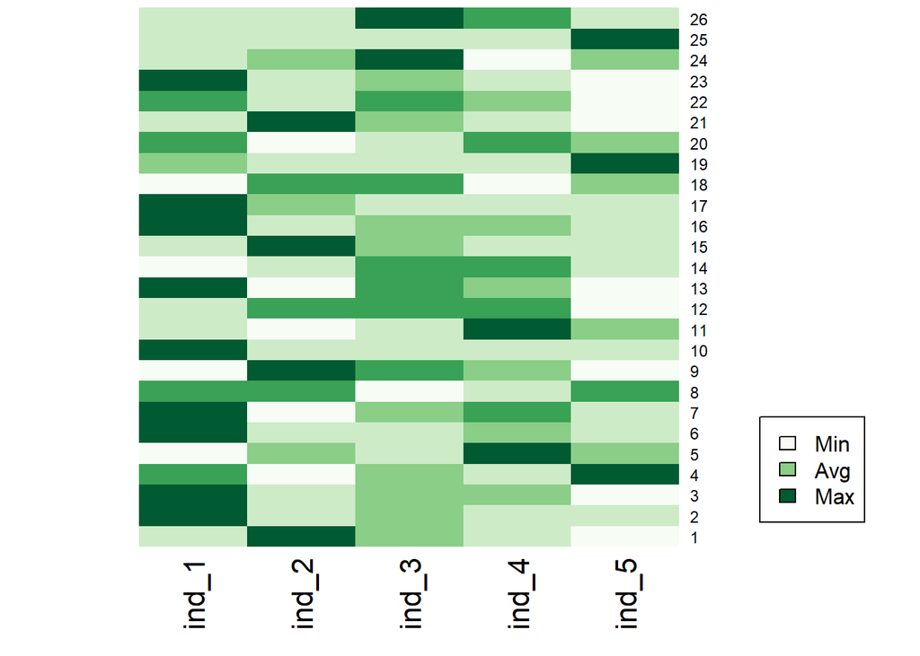

```r
words = read.table('https://www-cs-faculty.stanford.edu/~knuth/sgb-words.txt')

ind_words = connected_letters_vec(words, 'V1')

words_freq_by_ind = cbind.data.frame( # data frame of all letter freq by index
  as.data.frame(table(c(letters, strsplit(ind_words[1],   "")[[1]]))-1),
  as.data.frame(table(c(letters, strsplit(ind_words[2],   "")[[1]]))-1)$Freq,
  as.data.frame(table(c(letters, strsplit(ind_words[3],   "")[[1]]))-1)$Freq,
  as.data.frame(table(c(letters, strsplit(ind_words[4],   "")[[1]]))-1)$Freq,
  as.data.frame(table(c(letters, strsplit(ind_words[5],   "")[[1]]))-1)$Freq)

colnames(words_freq_by_ind) = c("Letter", "ind_1","ind_2","ind_3","ind_4","ind_5")


gen_heatmap(words_freq_by_ind)
```

##### b. function that receives guess words, corresponding matches and array of legal English words. return all the words in the dictionary that are consistent with the results of the previous guesses

```r
words_dict = array(words$V1)

matching_words_func = function(words_dictionary,guess,match_lst){
wanted_match = list()
final_match = c()
  for (i in 1:length(words_dictionary)){
    for (g in 1:length(guess)){
      wanted_match[[g]] = wordle_match(guess[[g]],words_dictionary[i])
      }
      if (identical(wanted_match, match_lst) == TRUE){
        final_match = c(final_match, words_dictionary[i])
      }
    }
  as.vector(final_match)
}

matching_words_func(words_dict,c("south","north"),list(c(-1,1,1,0,0),c(0,1,0,0,0)))
```

```
##  [1] "mouse" "lousy" "louse" "fouls" "douse" "louis" "coups" "mousy" "poufs"
## [10] "youse"
```

Implementing the function of given matches and words gave us the corresponding vector of words.

**strategy 1:** - We start with a random word with each letter sampled uniformly and independently from the $26$ English letters. - Then, at each turn, we look only at the previous perfect matches (`correct`) to the target word, and ignore matches at the `wrong` location and missing letters. At each place where there is a correct match, we use the correct letter, and at all other locations we keep sampling uniformly from the $26$ letters. We keep going until we get all the five letters correctly (and hence the word).

### 6. Implementing

```r
set.seed(3)

gen_word_by_guess = function(ctr,random_letters, right_word, is_printed = FALSE){ # Strategy 1
  vec = random_letters
  guess = paste(vec, collapse = '')
  right_splitted = strsplit(right_word, '')[[1]]
  while (guess != right_word){

    if (vec[1] != right_splitted[1]){
      vec[1] = sample(letters, 1)
      }

    if (vec[2] != right_splitted[2]){
      vec[2] = sample(letters, 1)
      }

    if (vec[3] != right_splitted[3]){
      vec[3] = sample(letters, 1)
      }

    if (vec[4] != right_splitted[4]){
      vec[4] = sample(letters, 1)
      }

    if (vec[5] != right_splitted[5]){
      vec[5] = sample(letters, 1)
      }

    guess = paste(vec, collapse = '')
    ctr = ctr + 1
    if (is_printed == TRUE){
      print(c(ctr, guess,  paste(wordle_match(guess,right_word), collapse = ' ' )))
    }
  }
    if (is_printed == TRUE){
    paste0(ctr, ' guesses.')}
    else{
    ctr}
  }

wordle_by_strat1 = function(right_word, is_printed){
  random_letters = as.vector(sample(letters, 5))
  rand_word = paste(random_letters, collapse = '')
  num_guess = 1
  if (is_printed == TRUE){
      print(c('Turn: ', ' Guess: ', '  Match:'))
  print(c(num_guess, rand_word, paste(wordle_match(rand_word,right_word), collapse = ' ' )))
    }
  gen_word_by_guess(num_guess, random_letters, right_word, is_printed)
}

wordle_by_strat1("mouse", TRUE)
```

```
## [1] "Turn: "   " Guess: " "  Match:"
## [1] "1"          "elgdh"      "-1 0 0 0 0"
## [1] "2"         "khtjw"     "0 0 0 0 0"
## [1] "3"         "hphhe"     "0 0 0 0 1"
## [1] "4"           "blmee"       "0 0 -1 -1 1"
## [1] "5"          "heiie"      "0 -1 0 0 1"
## [1] "6"         "xvrpe"     "0 0 0 0 1"
## [1] "7"         "ylhve"     "0 0 0 0 1"
## [1] "8"           "sfhoe"       "-1 0 0 -1 1"
## [1] "9"         "jkwce"     "0 0 0 0 1"
## [1] "10"         "ewvhe"      "-1 0 0 0 1"
## [1] "11"        "jdase"     "0 0 0 1 1"
## [1] "12"        "ftyse"     "0 0 0 1 1"
## [1] "13"         "zmgse"      "0 -1 0 1 1"
## [1] "14"        "zaise"     "0 0 0 1 1"
```

[output cut: 44 more lines]

We can see in this simulation it took 56 guesses in order to get the right word. It is not optimal.

##### b. mathematical formula for the distribution of the number of turns needed to guess the target word with strategy 1.

Define random variable $x_i$ : number of turns until right guess of single letter in a word.
$$\\[ x_i\\sim
{\\sf\^{iid} Geo}(\\frac{1}{26} ) \\$$

In our case all words are five letter words hence number of turns can be refered as:
$$\\[
\\sum\_{i = 1}\^{5}x_i\\$$
Hence,
$$\\[Pr(\\sum\_{i =
1}\^{5}x_i \< t) = \\prod\_{x = 1}\^{5}1 -
(1-1/26)\^{t-1} =\^{iid} (1 - (1-1/26)\^{t-1})\^5\\$$
From basic probability we know that:
$$\\[Pr(x=t) = Pr(x\<t+1) -
Pr(x\<t) \\$$
Hence:
$$\\[Pr(\\sum\_{i = 1}\^{5}x_i =
t) = (1 - (1-1/26)\^{(t+1)-1})\^5 - (1 -
(1-1/26)\^{t-1})\^5\\$$

$$\\[Pr(\\sum\_{i
= 1}\^{5}x_i = t) = (1 - (1-1/26)\^{t})\^5 - (1 -
(1-1/26)\^{t-1})\^5\\$$
Now when we have $Pr(\sum_{i = 1}^{5}x_i = t)$ we can compute the expected value.

By the instructions we would not take infinite sum, say we take sum over 2015 (number of five letter words):

```r
p_five_letters_t = function(t){
  return ((1 - (1-1/26)^t)^5 - (1 - (1-1/26)^(t-1))^5)
}
expected_values = c()
for (t in seq(1, 2015)){
  expected_values= c(expected_values, p_five_letters_t(t)*t)
}

sum(expected_values)
```

```
## [1] 58.71754
```

(Close result to the number of guesses we got on 6a).

##### c. simulate strategy 1 a 100 times with unknown words, plot the results and mean.

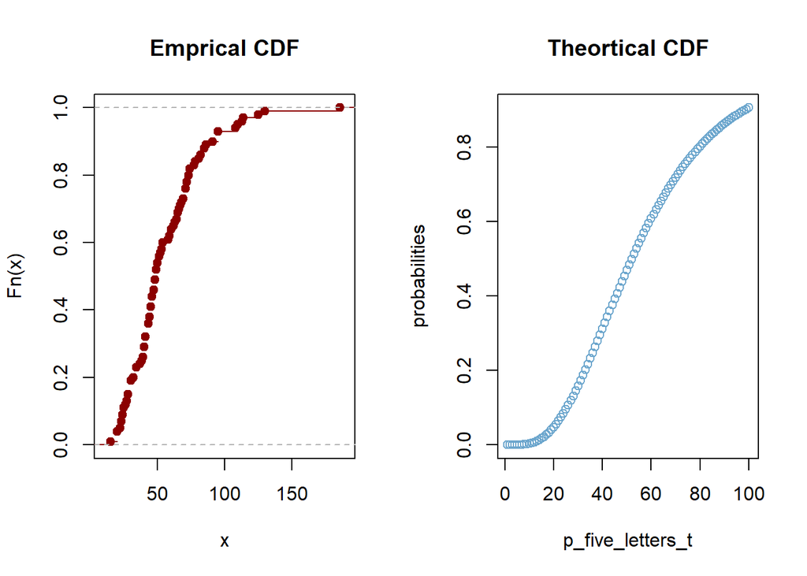

```r
set.seed(6)

rand_words = sample(as.vector(words$V1), 100)

turns = c()
for (i in 1:length(rand_words)){
  turns[i] = wordle_by_strat1(rand_words[i], FALSE)
}

probs_to_cumsum = c()
gen_theoretival_cdf = function(probs){
  for (i in 1:100){
    probs[i] = p_five_letters_t(i)
  }
  cumsum(probs)
}
probs_to_cumsum = gen_theoretival_cdf(probs_to_cumsum)

par(mfrow=c(1,2))
plot(ecdf(turns), col = 'darkred', xlim=c(10,190), main = "Emprical CDF") # ecdf of simulation

plot(probs_to_cumsum, col = "skyblue3", main = "Theortical CDF", xlab = 'p_five_letters_t', ylab = 'probabilities')
```

```r
print(paste0('The average number of turns :' ,mean(turns)))
```

```
## [1] "The average number of turns :56.07"
```

**Strategy 2:** - At each stage, we guess the word with the highest likelihood (see Qu. 4.c.), **of the remaining words that are consistent with the previous guesses**. - We keep guessing until obtaining the correct word.

**Strategy 3:** The same as strategy 2, but at each stage we guess a random word sampled uniformly from all remaining consistent words (instead of guessing the word with the highest likelihood).

Run both strategies with the unknown word “mouse”, and show the guesses and the number of turns for them, in similar to Qu. 6.a.

### 7. Implement 2 more strategies

```r
set.seed(678)

letter_probs2 = gen_letter_probs(words_freq_by_ind)

word_by_estimators2 = words %>% group_by(V1) %>% summarise(MLE = generate_est(V1,letter_probs2))
word_by_estimators2 = word_by_estimators2[order(word_by_estimators2$MLE,
decreasing = TRUE), ]


word_2_dict = as.vector(word_by_estimators2$V1)

wordle_by_strat2 = function(right_word, is_printed){

  dict = word_2_dict
  guess = dict[1]
  guess_vec = c(guess)
  ctr = 1
  if (is_printed == TRUE){
      print(c('Turn: ', ' Guess: ', '  Match:'))
  print(c(ctr, guess, paste(wordle_match(guess,right_word), collapse = ' ' )))
    }
  while (guess != right_word){
    dict = matching_words_func(dict, guess,
                                 list(wordle_match(guess,right_word)))

    guess = dict[1]
    guess_vec = c(guess_vec, guess)
    ctr = ctr + 1
    if (is_printed == TRUE){
      print(c(ctr, guess,  paste(wordle_match(guess,right_word), collapse = ' ' )))
    }
  }
  if (is_printed == TRUE){
    print(paste0(ctr, ' guesses.'))
    print(guess_vec)}
    else{
    ctr}
}

wordle_by_strat2("mouse", TRUE)
```

```
## [1] "Turn: "   " Guess: " "  Match:"
## [1] "1"            "sores"        "-1 1 0 -1 -1"
## [1] "2"         "poise"     "0 1 0 1 1"
## [1] "3"          "moose"      "1 1 -1 1 1"
## [1] "4"         "mouse"     "1 1 1 1 1"
## [1] "4 guesses."
## [1] "sores" "poise" "moose" "mouse"
```

```r
wordle_by_strat3 = function(right_word, is_printed){
  dict = word_2_dict
  guess = sample(dict,1)
  guess_vec = c(guess)
  ctr = 1
  if (is_printed == TRUE){
      print(c('Turn: ', ' Guess: ', '  Match:'))
  print(c(ctr, guess, paste(wordle_match(guess,right_word), collapse = ' ' )))
    }
  while (guess != right_word){
    dict = matching_words_func(dict, guess,
                                 list(wordle_match(guess,right_word)))
    guess = sample(dict,1)
    guess_vec = c(guess_vec, guess)
    ctr = ctr + 1
    if (is_printed == TRUE){
      print(c(ctr, guess,  paste(wordle_match(guess,right_word), collapse = ' ' )))
    }
  }
  if (is_printed == TRUE){
    print(paste0(ctr, ' guesses.'))
    print(guess_vec)}
    else{
    ctr}
}

wordle_by_strat3("mouse", TRUE)
```

```
## [1] "Turn: "   " Guess: " "  Match:"
## [1] "1"           "harem"       "0 0 0 -1 -1"
## [1] "2"          "munge"      "1 -1 0 0 1"
## [1] "3"         "mouse"     "1 1 1 1 1"
## [1] "3 guesses."
## [1] "harem" "munge" "mouse"
```

The new strategies seems to be a better approach than the first (naive implementation). we got much better results for the unknown word “mouse”.

##### b. simulate both strategies a 100 times with unknown words, plot the results and mean

```r
set.seed(9)

wordle_by_strat2_light_func = function(right_word){
  dict = word_2_dict
  guess = dict[1]
  ctr = 1
  while(guess != right_word){
    dict = matching_words_func(dict, guess,
                                 list(wordle_match(guess,right_word)))

    guess = dict[1]
    ctr = ctr + 1
  }
  ctr
}


rand_words2_3 = sample(word_2_dict, 100)

turns2 = c()
for (i in 1:length(rand_words)){
  turns2[i] = wordle_by_strat2_light_func(rand_words2_3[i])
}
```

```r
set.seed(9)

wordle_by_strat3_light_func = function(right_word, is_printed){
  dict = word_2_dict
  guess = sample(dict,1)
  ctr = 1
  while(guess != right_word){
    dict = matching_words_func(dict, guess,
                                 list(wordle_match(guess,right_word)))
    guess = sample(dict,1)
    ctr = ctr + 1
  }

  ctr
}

rand_words2_3 = sample(word_2_dict, 100)

turns3 = c()
for (i in 1:length(rand_words)){
  turns3[i] = wordle_by_strat3_light_func(rand_words2_3[i])
}
```

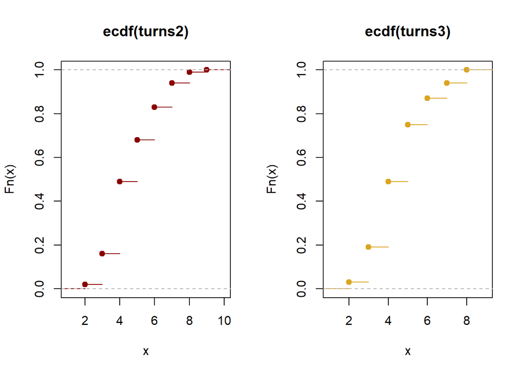

```r
par(mfrow=c(1,2))

plot(ecdf(turns2), col = 'darkred') # ecdf of simulation
plot(ecdf(turns3), col = 'goldenrod') # ecdf of simulation
```

```r
print(paste0('The average number of turns_2: ' ,mean(turns2)))
```

```
## [1] "The average number of turns_2: 4.89"
```

```r
print(paste0('The average number of turns_3: ' ,mean(turns3)))
```

```
## [1] "The average number of turns_3: 4.73"
```

First, looking at the average number of turns in the simulation we can confirm that the new methods ar far more efficient. The ecdf for both strategies looks about the same except for, strategy 2 tend for more dramatic jumps at the beginning and lower at the end which strategy 3 does less dramatic. Compare to strategy 1 the ecdf looks a lot different because of the far less moves needed for the guess.